# R Notebook

[figure not shown]

## 공지

본 블로그는 2020-04-08에 소개된 [Great Looking Tables: gt(v0.2) by Richard Iannone(https://blog.rstudio.com/2020/04/08/great-looking-tables-gt-0-2/)글을 번역한 것이다. 함수와 관련된 설명은 가급적 원어를 직접 인용 했으니, 영어로 직접 함수의 사용처를 음미하시길 바란다.

## I. Intro

`gt`라는 이름은 `grammar of tables`즉 “테이블의 문법”의 줄임말이며 `gt`의 목표는 `ggplot2`와 비슷하게 운영하는 것이다. 특정 테이블을 쉽게 만들 수 있을 뿐만 아니라 다양한 문제를 해결하기 위해 서로 다른 방법으로 재결합할 수 있는 기본 구성요소 집합을 기술하는 역할을 한다.

`R` 사용자가 맞춤형(`customized`) 테이블을 `R Markdown`에서 만들 필요가 있다면, `gt` 패키지가 그 과정에 도움을 줄 것이다. 패키지를 설치해보자.

```r
# install.packages("gt")
library(gt)
```

표를 구성하고, 서식과 주석을 적용하며, 원하는 대로 스타일을 만드는 방법은 매우 다양하다. 현재 `gt`는 테이블을 `HTML` 출력 형식으로 렌더링하고 있으며 이미지 파일로 내보낼 수 있는 기능을 가지고 있다. 조만간 `LaTeX`와 `RTF` 출력 포맷도 지원할 계획이다.

gt 패키지의 [Website](https://gt.rstudio.com/)에는 시작하기 위한 문서와 테이블 출력이 어떻게 나타나야 하는지를 보여주는 많은 예와 이미지가 있는 [다양한 funciton reference section](https://gt.rstudio.com/reference/index.html)이 있다.

## II. gt table structure

패키지의 저자가 고려한 것은 테이블의 구조를 파악해서 구조화 작업을 진행해야 하고, 이에 맞는 함수의 언어를 만드는 것이 필요했다. 아래 그림에서 보는 것처럼, 테이블(위에서 아래로 내려가면서)은 크게 `Table Header`, `Column Lables`, `stub and stub head`, `table body`, `table footer`이 포함된다. 이러한 각 구성 요소에는 하위 구성 요소가 있을 수 있다(예: `table header`에는 `title` & `subtitle`가 들어 있으며 `table body`에는 `individual cells` 을 포함하고 있다). 아래 그림을 통해서 다시한번 각 구조에 대해 파악하도록 한다.

[figure not shown]

새로운 문법을 배우는 것은 분명 고통이 수반된다. 그러나 `ggplot2`와 같이, 새로운 단어들은 익숙해지는 데 다소 시간이 걸리지만, 우리는 그것들을 배우는 것이 기존의 표를 분석하고 이해하는 능력을 향상시켜 `gt`로 성공적으로 재현할 것이라고 믿는다.

## (1) Hello World

어느 문법이나 `Hello World`는 존재한다. `exibble` 데이터 집합은 `gt`에 포함되며, 다양한 데이터를 실험하기 위한 데이터셋을 준비했다.

```r
library(gt)
library(dplyr)
glimpse(exibble)
```

8개의 row와 9개의 column으로 구성되어 있고, 숫자, 문자, 범주형, 날짜까지, 모든 종류의 데이터가 종류해도 무방하다. 기존의 데이터셋을 `gt()`로 바꿔주는 것이 중요하다. `ggplot()`에 데이터셋을 입력하는 형태를 기억해보자.

```r
library(ggplot2)
data %>%
  ggplot()
```

이 문법을 기억하면 좋을 것 같다.

```r
exibble %>% gt()
```

## (2) Formatting data in columns

`exibble` 데이터셋에는 다양한 열 유형이 포함되어 있음을 기억하고 있다. 이것은 입력 데이터 값을 포맷하는 `gt`의 `fmt_*()` 함수를 활용하여 정리를 해보자. 가급적 원어를 그대로 정리하였다.

```r
exibble %>%
  gt() %>%
  fmt_number(columns = vars(num), decimals = 2) %>%
  fmt_date(columns = vars(date), date_style = 6) %>%
  fmt_time(columns = vars(time), time_style = 4) %>%
  fmt_datetime(columns = vars(datetime), date_style = 6, time_style = 4) %>%
  fmt_currency(columns = vars(currency), currency = "KRW")
```

> 번역시, 추가 내용, 위 함수에서 한국 사람들이 궁금해 할, `KRW`가 있는지 확인해봤다. 다행히 존재하였다. 확인하는 방법은 `info_currencies(begins_with = "k")`를 입력하면 `k`를 가지고 있는 다양한 나라의 화폐단위를 확인할 수 있고, 해당 문자열 코드를 `KRW` 대신 입력하면 된다.

```r
info_currencies(begins_with = "k")
```

사용자들이 기대했던 것처럼, 전체 Column에는 매우 구체적인 방법으로 서식이 적용되었다. 좀 더 디테일한 수정도 가능하다. 특정 열에 있는 행의 하위 선택 유형을 지정할 수 있으며, 대상 행을 지정하는 방법(예: 행 색인, 스텁의 행 이름, 열 데이터에 기초한 조건문 등)이 상당히 많다.

조금 더 테이블을 입맛에 맞게 수정하고 싶다면, 더 많은 `fmt_*()` 함수가 있다. 물론, 이러한 함수들이 사용자나 또는 클라이언트의 요구에 정확히 부합하지 않는다면 사용자는 일반적인 `fmt()` 함수를 사용하고 특정 부분에는 사용자 정의 함수 또는 응용해서 가공할 수도 있다.

## (3) A table with a header and a footer

`테이블`에 몇몇 구성품을 추가할 수 있다. `제목(title)`과 `부제(subtitle)`가 있는 `머리글(header)`과 `소스 노트(source_note)`가 있는 `바닥글(footer)`을 포함 할 수 있다. 이 때에는 `tab_header()` 및 `tab_source_note()` 함수가 사용될 것이다.

```r
exibble %>%
  gt() %>%
  tab_header(
    title = md("**gt** 패키지 내부에 있는 `exibble` 데이터셋  "),
    subtitle = "gt 패키지에는 6개의 데이터셋이 더 존재한다."
  ) %>%
  tab_source_note(md("More information is available at `?exibble`."))
```

기존 테이블에 parts 부분들이 들어간다면 `tab_*()` 함수가 사용되어질 것이다. 또한 `Markdown` 형태의 함수(`md()`)가 사용되는 이유는 `markdown style`을 테이블에 적용하기 때문이다.

## (4) Adding a stub and organizing rows into row groups

`exibble` 데이터셋은 행과 `group columns`로 이루어진 것을 알 수 있습니다. 이 때, `gt(rowname_col = "row", groupname_col = "group")`을 추가한다. 여기에서 `stub`이라는 문법은 조금 생소하기 때문에 아래 그림을 통해서 다시한번 확인하도록 한다.

[figure not shown]

부가적인 설명보다는 코드를 통해서 어떻게 결과값이 출력되는 확인해보자.

```r
exibble %>%
  gt(rowname_col = "row", groupname_col = "group") %>%
  tab_header(
    title = md("**gt** 패키지 내부에 있는 `exibble` 데이터셋  "),
    subtitle = "gt 패키지에는 6개의 데이터셋이 더 존재한다."
  ) %>%
  tab_source_note(md("More information is available at `?exibble`."))
```

이러한 변화를 통해서 테이블 왼쪽의 영역(`stub`)에 행 레이블과 각 행 그룹위에 있는 행 그룹 레이블을 효과적으로 제공하는 것을 볼 수 있다. 만약에 행 그룹의 순서를 다시 정렬하고 싶다면, `row_group_order()` 함수를 사용하여 그룹화를 다시 정렬한다.

```r
exibble %>%
  gt(rowname_col = "row", groupname_col = "group") %>%
  tab_header(
    title = md("**gt** 패키지 내부에 있는 `exibble` 데이터셋  "),
    subtitle = "gt 패키지에는 6개의 데이터셋이 더 존재한다."
  ) %>%
  tab_source_note(md("More information is available at `?exibble`.")) %>%
  row_group_order(
    groups = c("grp_b", "grp_a")
  )
```

## (5) Using spanner column labels

`stub`과 같이, 하나 이상의 열을 포함하는 `spanner column` 레이블을 통해 열 그룹화를 만들 수 있다. `tab_spanner()` 함수가 이러한 기능을 제공하는데, 라벨과 열 선택을 통해 새 라벨이 해당 열 위에 배치되고 관련 수평 규칙은 가로로 확장된다. 열이 서로 인접하지 않는다면 `tab_spanner()`가 자동으로 함께 모이게 된다.

```r
exibble %>%
  gt(rowname_col = "row", groupname_col = "group") %>%
  tab_spanner(label = "날짜와 시간 Tab", columns = matches("date|time")) %>%
  tab_header(
    title = md("**gt** 패키지 내부에 있는 `exibble` 데이터셋  "),
    subtitle = "gt 패키지에는 6개의 데이터셋이 더 존재한다."
  ) %>%
  tab_source_note(md("More information is available at `?exibble`.")) %>%
  row_group_order(
    groups = c("grp_b", "grp_a")
  )
```

`tab_spanner(label = "날짜와 시간 Tab", columns = matches("date|time"))` 소스코드를 추가하면 되는데, `matches("date|time")` 문법은 `dplyr 패키지`내의 함수로 `date` 또는 `time` 열을 가져오라는 뜻이다.

## (1) gt Test Drive

짧게 소개하는 글이기 때문에, 이것으로 사용자의 만족을 기대할 수는 없다. `RStudio Cloud` 사용자라면 `gt Test Drive`에 있는 소스코드를 활용하는 것도 좋다.

- [gt Test Drive](https://rstudio.cloud/project/779965)

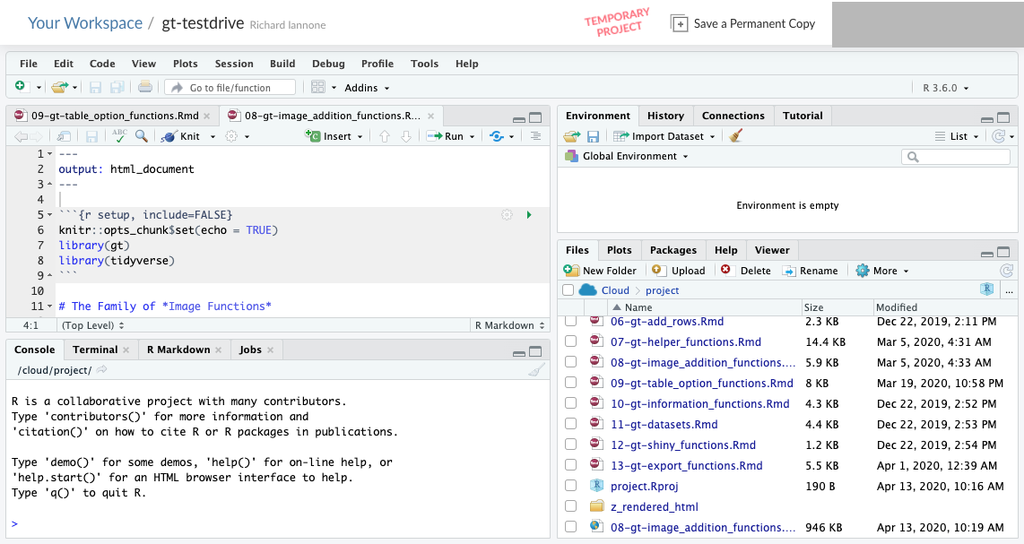

## (3) 색상, 이미지 입히기 (소스코드 별도)

각주 삽입, 텍스트, 테두리 및 채우기 수정, 요약 행 추가와 같은 훨씬 더 유용한 작업을 수행할 수 있다. 본 블로그에서는 제공되지 않고, 대신 관련 코드를 제공한다. ([available in this gist](https://gist.github.com/rich-iannone/1da1ae7a7203958a0c5b1bd1d4b24017))

그러나, 번역시 가져왔다. 다행히 에러없이 잘 수행된다!

```r
library(tidyverse)
library(paletteer)
library(gt)

pizzaplace %>%
  mutate(type = case_when(
    type == "chicken" ~ "chicken (pizzas with chicken as a major ingredient)",
    type == "classic" ~ "classic (classical pizzas)",
    type == "supreme" ~ "supreme (pizzas that try a little harder)",
    type == "veggie" ~ "veggie (pizzas without any meats whatsoever)",
  )) %>%
  mutate(size = factor(size, levels = c("S", "M", "L", "XL", "XXL"))) %>%
  dplyr::group_by(type, size) %>%
  dplyr::summarize(
    sold = n(),
    income = sum(price)
  ) %>%
  gt(rowname_col = "size") %>%
  tab_header(title = md("&#127829; Pizzas Sold in 2015 &#127829;")) %>%
  fmt_number(
    columns = vars(sold),
    decimals = 0,
    use_seps = TRUE
  ) %>%
  fmt_currency(
    columns = vars(income),
    currency = "USD"
  ) %>%
  cols_align(align = "right", columns = TRUE) %>%
  data_color(
    columns = vars(sold, income),
    colors = scales::col_numeric(
      palette = paletteer::paletteer_d(
        palette = "ggsci::red_material"
      ) %>% as.character(),
      domain = NULL
    ),
    alpha = 0.8
  ) %>%
  summary_rows(
    groups = TRUE,
    columns = vars(sold),
    fns = list(TOTAL = "sum"),
    formatter = fmt_number,
    decimals = 0,
    use_seps = TRUE
  ) %>%
  summary_rows(
    groups = TRUE,
    columns = vars(income),
    fns = list(TOTAL = "sum"),
    formatter = fmt_currency,
    currency = "USD"
  ) %>%
  grand_summary_rows(
    columns = vars(sold),
    fns = list(`GRAND TOTAL` = "sum"),
    formatter = fmt_number,
    decimals = 0,
    use_seps = TRUE
  ) %>%
  grand_summary_rows(
    columns = vars(income),
    fns = list(`GRAND TOTAL` = "sum"),
    formatter = fmt_currency,
    currency = "USD"
  ) %>%
  tab_footnote(
    footnote = "The pizza category with the highest total sales.",
    locations = cells_row_groups("classic (classical pizzas)")
  ) %>%
  tab_footnote(
    footnote = md("Custom sizes for **The Greek** pizza."),
    locations = cells_stub(c("XL", "XXL"))
  ) %>%
  tab_footnote(
    footnote = md("This is a new record. Truly, 2015 was a **great** year for the `pizzaplace`."),
    locations = cells_grand_summary(columns = vars(sold))
  ) %>%
  tab_options(
    summary_row.background.color = "#ACEACE80",
    grand_summary_row.background.color = "#990000",
    row_group.background.color = "#FFEFDB80",
    heading.background.color = "#EFFBFC",
    column_labels.background.color = "#EFFBFC",
    stub.background.color = "#EFFBFC",
    table.font.color = "#323232",
    table_body.hlines.color = "#989898",
    table_body.border.top.color = "#989898",
    heading.border.bottom.color = "#989898",
    row_group.border.top.color = "#989898",
    row_group.border.bottom.style = "none",
    stub.border.style = "dashed",
    stub.border.color = "#989898",
    stub.border.width = "1px",
    summary_row.border.color = "#989898",
    table.width = "60%"
  ) %>%
  opt_all_caps()
```

## 결론: 번역 시, 느낀점.

`grammar of tables` 이 한 단어로 향후 R Studio에서 `테이블` 다루는 문법이 어떤 형태로 발전하는지 보여주는 좋은 예가 될 것 같다. 기존에는 굉장히 많은 종류의 테이블 관련 패키지가 존재하였지만, 문법적으로 일치가 되지는 않았다. `ggplot2`에서 발전한 다양한 `extension` 패키지가 있는 것을 고려하면, `table` 역시 그러한 형태로 발전할 것은 분명해 보인다.